# Affair-data-analysis

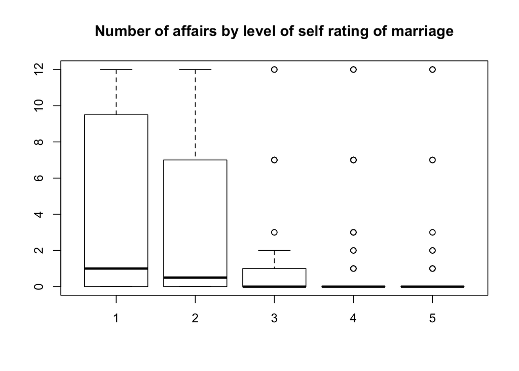

```r
boxplot(df$nbaffairs ~ df$rate, df, main="Number of affairs by level of self rating of marriage")
```

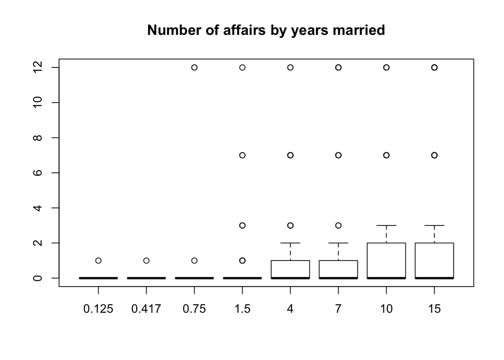

```r
boxplot(df$nbaffairs ~ df$ym, df, main="Number of affairs by years married")
```

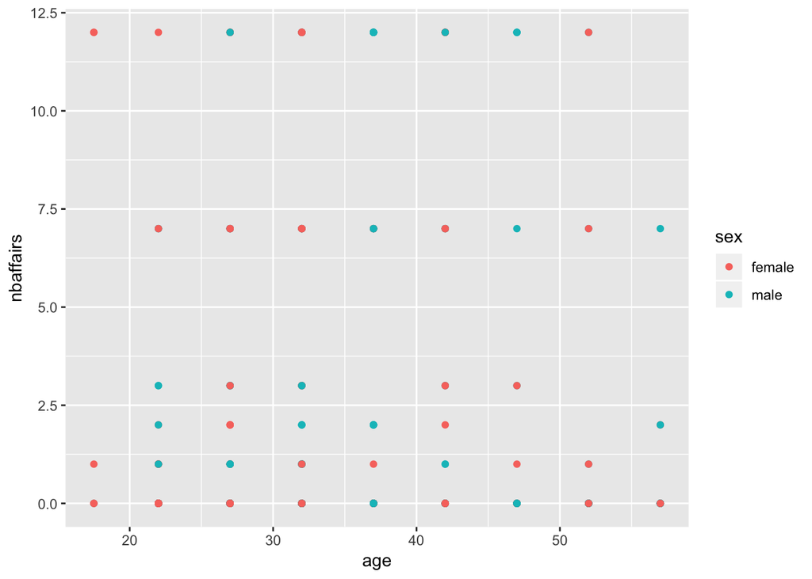

```r
ggplot(df,
       aes(x=age, y=nbaffairs,
           colour=sex
       )
) + geom_point()
```

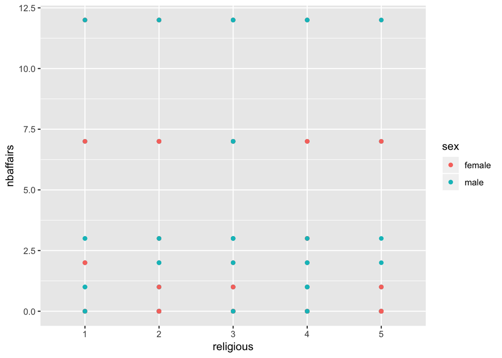

```r
ggplot(df,
       aes(x=religious, y=nbaffairs,
           colour=sex
       )
) + geom_point()
```

```r
table(df$nbaffairs)
```

```
##
##   0   1   2   3   7  12
## 451  34  17  19  42  38
```

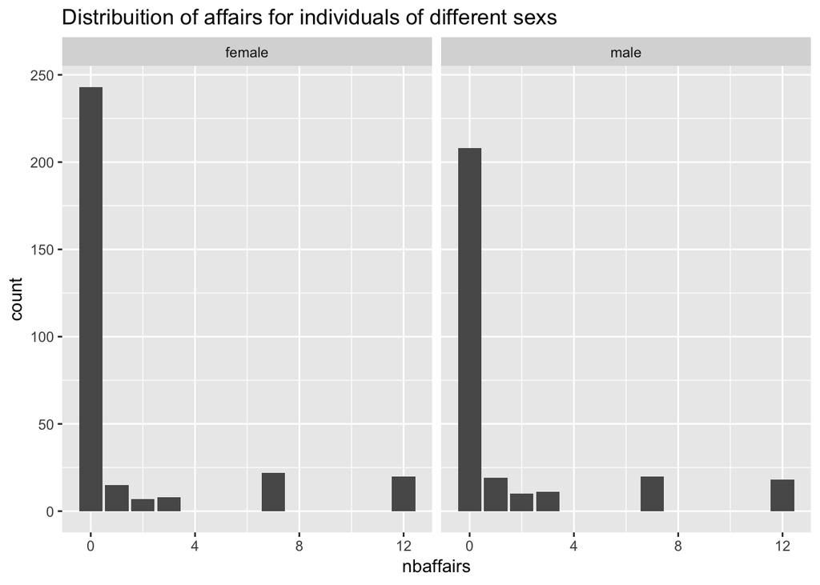

```r
ggplot(df,aes(x=nbaffairs)) + geom_bar() + facet_wrap(~ sex) + ggtitle("Distribuition of affairs for individuals of different sexs")
```

```r
table(df$sex)
```

```
##
## female   male
##    315    286
```

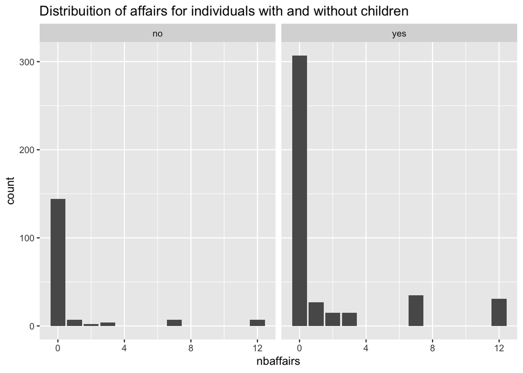

```r
ggplot(df,aes(x=nbaffairs)) + geom_bar() + facet_wrap(~ child) + ggtitle("Distribuition of affairs for individuals with and without children")
```

```r
table(df$child)
```

```
##
##  no yes
## 171 430
```

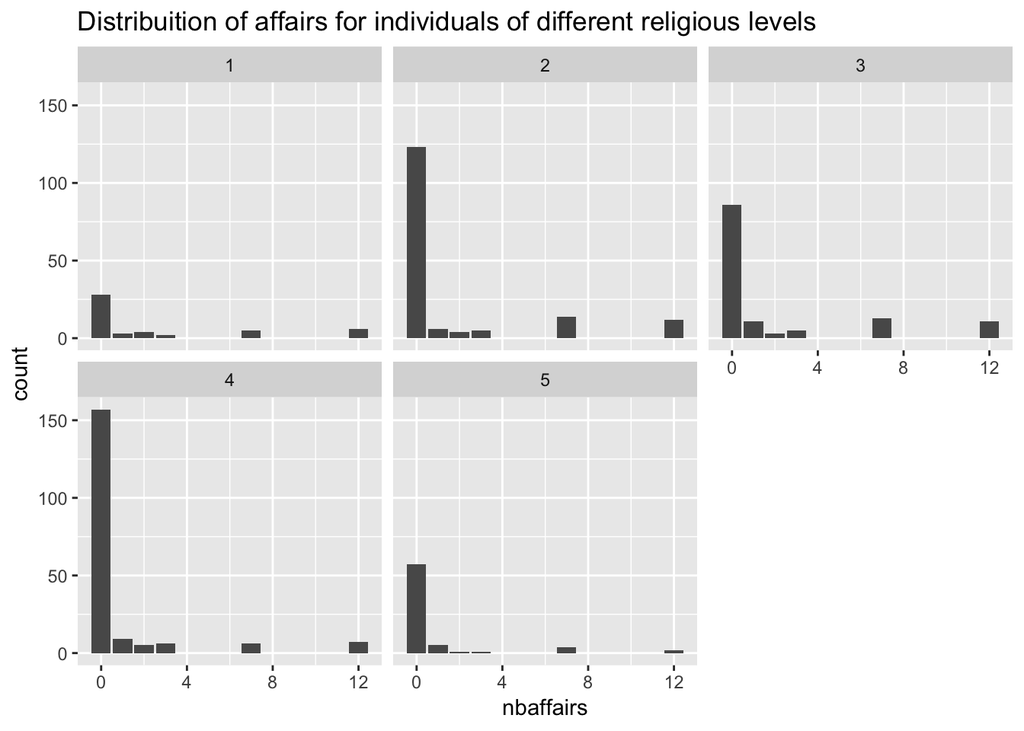

```r
ggplot(df,aes(x=nbaffairs)) + geom_bar() + facet_wrap(~ religious) + ggtitle("Distribuition of affairs for individuals of different religious levels")
```

```r
table(df$religious)
```

```
##
##   1   2   3   4   5
##  48 164 129 190  70
```

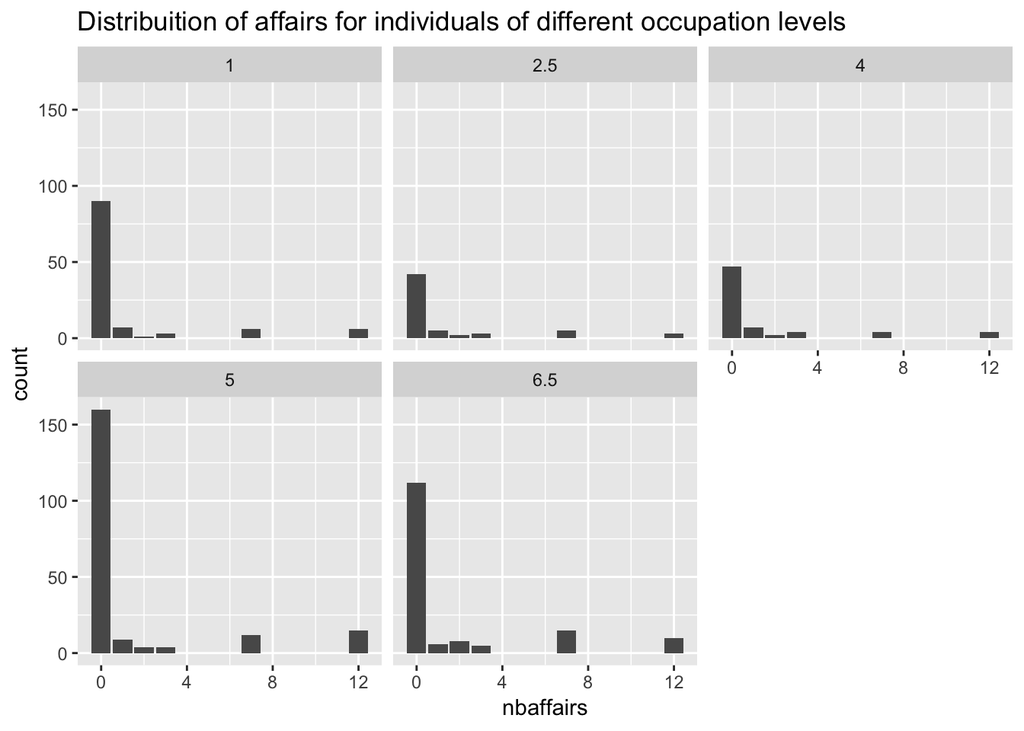

```r
ggplot(df,aes(x=nbaffairs)) + geom_bar() + facet_wrap(~ occupation) + ggtitle("Distribuition of affairs for individuals of different occupation levels")
```

```r
table(df$occupation)
```

```
##
##   1 2.5   4   5 6.5
## 113  60  68 204 156
```

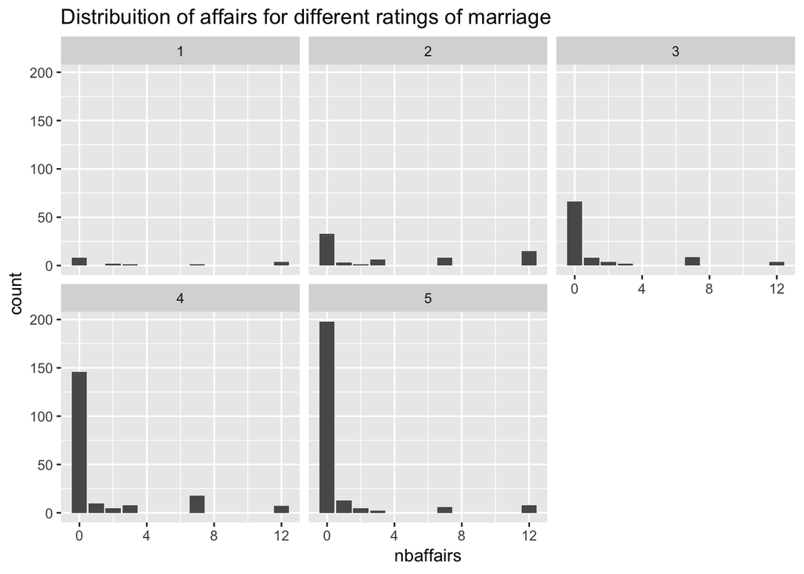

```r
ggplot(df,aes(x=nbaffairs)) + geom_bar() + facet_wrap(~ rate) + ggtitle("Distribuition of affairs for different ratings of marriage")
```

```r
table(df$rate)
```

```
##
##   1   2   3   4   5
##  16  66  93 194 232
```

Algumas notas relevantes:

- O dataset contem 601 observações
- A idade média é de ~32 anos e meio
- A proporção de individuos do sexo feminino é 0.524 e do sexo masculino é de 0.476
- 430 dos participantes têm filhos enquanto que 171 não têm.
- 451 não tiveram casos no último ano. 150 tiveram pelo menos um.

```r
dfChild <- df[as.character(df$child) == "yes", ]
table(dfChild$nbaffairs)
```

```
##
##   0   1   2   3   7  12
## 307  27  15  15  35  31
```

```r
dfym10 <- df[as.character(df$ym) >= 10, ]
table(dfym10$nbaffairs)
```

```
##
##   0   1   2   3   7  12
## 328  25  17  16  40  35
```

```r
dfym10 <- df[as.character(df$ym) < 10, ]
table(dfym10$nbaffairs)
```

```
##
##   0   1   3   7  12
## 123   9   3   2   3
```

- dos casados há mais de 10 anos (461 indivíduos), 133 tiveram casos, ~29%.
- dos casados há menos de 10 anos (140 indivíduos), 17 tiveram casos, ~12%.

```r
corMatrix <- cor(df[, c("age", "ym", "education", "nbaffairs")])
corMatrix
```

```
##                 age         ym    education    nbaffairs
## age       1.0000000 0.77754585  0.134596015  0.095237204
## ym        0.7775458 1.00000000  0.040002716  0.186841686
## education 0.1345960 0.04000272  1.000000000 -0.002437441
## nbaffairs 0.0952372 0.18684169 -0.002437441  1.000000000
```

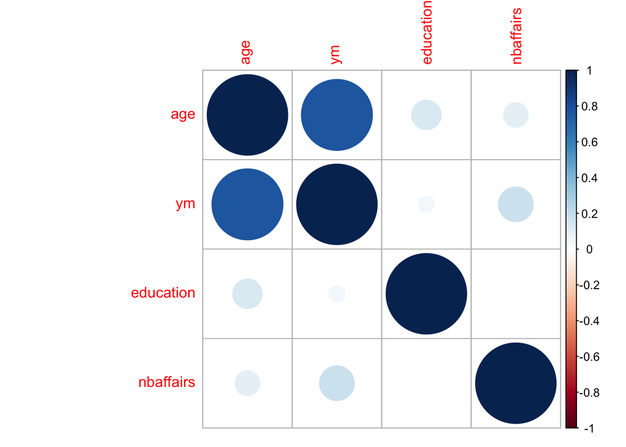

```r
corrplot(corMatrix, method="circle")
```

# Regressão Linear

## Regressão Linear Simples

```r
sex <- lm(nbaffairs ~ sex, df)
age <- lm(nbaffairs ~ age, df)
ym <- lm(nbaffairs ~ ym, df)
child<- lm(nbaffairs ~ child, df)
religious <- lm(nbaffairs ~ religious, df)
education <- lm(nbaffairs ~ education, df)
occupation <- lm(nbaffairs ~ occupation, df)
rate <- lm(nbaffairs ~ rate, df)
screenreg(list(sex, age, ym, child, religious, education, occupation, rate))
```

```
##
## ========================================================================================================
##                Model 1     Model 2   Model 3     Model 4     Model 5     Model 6  Model 7     Model 8
## --------------------------------------------------------------------------------------------------------
## (Intercept)      1.42 ***    0.36      0.55 *      0.91 ***    2.58 ***    1.51     1.17 ***    3.87 ***
##                 (0.19)      (0.49)    (0.24)      (0.25)      (0.47)      (0.92)   (0.31)      (0.79)
## sexmale          0.08
##                 (0.27)
## age                          0.03 *
##                             (0.01)
## ym                                     0.11 ***
##                                       (0.02)
## childyes                                           0.76 *
##                                                   (0.30)
## religious2                                                    -0.93
##                                                               (0.54)
## religious3                                                    -0.61
##                                                               (0.55)
## religious4                                                    -1.73 **
##                                                               (0.53)
## religious5                                                    -1.70 **
##                                                               (0.61)
## education                                                                 -0.00
##                                                                           (0.06)
## occupation2.5                                                                       0.32
##                                                                                    (0.53)
## occupation4                                                                         0.29
##                                                                                    (0.51)
## occupation5                                                                         0.27
##                                                                                    (0.39)
## occupation6.5                                                                       0.51
##                                                                                    (0.41)
## rate2                                                                                           0.05
##                                                                                                (0.88)
## rate3                                                                                          -2.44 **
##                                                                                                (0.85)
## rate4                                                                                          -2.57 **
##                                                                                                (0.82)
## rate5                                                                                          -3.16 ***
##                                                                                                (0.81)
## --------------------------------------------------------------------------------------------------------
## R^2              0.00        0.01      0.03        0.01        0.03        0.00     0.00        0.10
## Adj. R^2        -0.00        0.01      0.03        0.01        0.02       -0.00    -0.00        0.09
## Num. obs.      601         601       601         601         601         601      601         601
## RMSE             3.30        3.29      3.24        3.28        3.26        3.30     3.31        3.15
## ========================================================================================================
## *** p < 0.001, ** p < 0.01, * p < 0.05
```

Estes modelos indicam-nos também que o indivíduo ser do sexo masculino causa um ligeiro incremento (0.08) no número de casos previstos. Um incremento de um ano de idade causa um aumento de 0.03 na previsão dos casos extraconjugais.

## Regrassão Linear Multipla

Diversos modelos foram testados, mas começando pelos mais simples, o modelo completo e o modelo nulo.

```r
modCompleto <- lm(nbaffairs ~ ., df)
summary(modCompleto)
```

```
##
## Call:
## lm(formula = nbaffairs ~ ., data = df)
##
## Residuals:
##     Min      1Q  Median      3Q     Max
## -5.0518 -1.5583 -0.7057  0.1556 12.7204
##
## Coefficients:
##                Estimate Std. Error t value Pr(>|t|)
## (Intercept)    4.813260   1.415135   3.401 0.000717 ***
## sexmale        0.055288   0.316787   0.175 0.861512
## age           -0.051102   0.022601  -2.261 0.024126 *
## ym             0.172534   0.041256   4.182 3.33e-05 ***
## childyes      -0.158665   0.352149  -0.451 0.652472
## religious2    -1.136684   0.510860  -2.225 0.026461 *
## religious3    -0.876526   0.525981  -1.666 0.096159 .
## religious4    -1.995528   0.503298  -3.965 8.25e-05 ***
## religious5    -2.020156   0.589072  -3.429 0.000648 ***
## education     -0.005116   0.067786  -0.075 0.939865
## occupation2.5  0.324039   0.528268   0.613 0.539852
## occupation4    0.573943   0.513347   1.118 0.264010
## occupation5    0.501606   0.404727   1.239 0.215707
## occupation6.5  0.573232   0.494087   1.160 0.246448
## rate2          0.295574   0.863953   0.342 0.732386
## rate3         -2.038040   0.843013  -2.418 0.015930 *
## rate4         -2.222873   0.815026  -2.727 0.006576 **
## rate5         -2.563573   0.817331  -3.137 0.001796 **
## ---
## Signif. codes:  0 '***' 0.001 '**' 0.01 '*' 0.05 '.' 0.1 ' ' 1
##
## Residual standard error: 3.069 on 583 degrees of freedom
## Multiple R-squared:  0.1587, Adjusted R-squared:  0.1342
## F-statistic: 6.471 on 17 and 583 DF,  p-value: 3.718e-14
```

Como se pode ver, o R2 ajustado é bastante baixo, 0.1342. Isto é explicado pelo facto de estarmos a prever um resultado discreto usando um modelo contínuo.

```r
modNulo <- lm(nbaffairs ~ 1, df)
summary(modNulo)
```

```
##
## Call:
## lm(formula = nbaffairs ~ 1, data = df)
##
## Residuals:
##    Min     1Q Median     3Q    Max
## -1.456 -1.456 -1.456 -1.456 10.544
##
## Coefficients:
##             Estimate Std. Error t value Pr(>|t|)
## (Intercept)   1.4559     0.1346   10.82   <2e-16 ***
## ---
## Signif. codes:  0 '***' 0.001 '**' 0.01 '*' 0.05 '.' 0.1 ' ' 1
##
## Residual standard error: 3.299 on 600 degrees of freedom
```

Como são modelos encaixados podemos compara-los usando a anova:

```r
anova(modCompleto, modNulo)
```

```
## Analysis of Variance Table
##
## Model 1: nbaffairs ~ sex + age + ym + child + religious + education +
##     occupation + rate
## Model 2: nbaffairs ~ 1
##   Res.Df    RSS  Df Sum of Sq      F    Pr(>F)
## 1    583 5492.7
## 2    600 6529.1 -17   -1036.4 6.4706 3.718e-14 ***
## ---
## Signif. codes:  0 '***' 0.001 '**' 0.01 '*' 0.05 '.' 0.1 ' ' 1
```

O valor-F é significativo. Rejeitamos por isso a hipotese nula de que o modelo pequeno explica tanto como o grande.

Vamos agora selecionar as variáveis significativas.

```r
drop1(modCompleto, test = "F")
```

```
## Single term deletions
##
## Model:
## nbaffairs ~ sex + age + ym + child + religious + education +
##     occupation + rate
##            Df Sum of Sq    RSS    AIC F value    Pr(>F)
## <none>                  5492.7 1365.8
## sex         1      0.29 5493.0 1363.8  0.0305 0.8615118
## age         1     48.16 5540.9 1369.0  5.1122 0.0241258 *
## ym          1    164.78 5657.5 1381.5 17.4897 3.333e-05 ***
## child       1      1.91 5494.6 1364.0  0.2030 0.6524718
## religious   4    221.63 5714.4 1381.5  5.8810 0.0001209 ***
## education   1      0.05 5492.8 1363.8  0.0057 0.9398654
## occupation  4     18.00 5510.7 1359.7  0.4776 0.7521893
## rate        4    454.38 5947.1 1405.5 12.0571 2.018e-09 ***
## ---
## Signif. codes:  0 '***' 0.001 '**' 0.01 '*' 0.05 '.' 0.1 ' ' 1
```

Olhando para o output do drop1, as variáveis sex, child, education e occupation são candidatas a serem removidas pois o seu valor F não é significativo.

Vamos agora selecionar as variáveis significativas usando o método Backward no modelo completo, minimizando o AIC.

```r
modStep <- step(modCompleto, direction = c("backward"))
```

```
## Start:  AIC=1365.76
## nbaffairs ~ sex + age + ym + child + religious + education +
##     occupation + rate
##
##              Df Sum of Sq    RSS    AIC
## - occupation  4     18.00 5510.7 1359.7
## - education   1      0.05 5492.8 1363.8
## - sex         1      0.29 5493.0 1363.8
## - child       1      1.91 5494.6 1364.0
## <none>                    5492.7 1365.8
## - age         1     48.16 5540.9 1369.0
## - ym          1    164.78 5657.5 1381.5
## - religious   4    221.63 5714.4 1381.5
## - rate        4    454.38 5947.1 1405.5
##
## Step:  AIC=1359.73
## nbaffairs ~ sex + age + ym + child + religious + education +
##     rate
##
##             Df Sum of Sq    RSS    AIC
## - education  1      0.91 5511.6 1357.8
## - sex        1      5.32 5516.0 1358.3
## - child      1      5.37 5516.1 1358.3
## <none>                   5510.7 1359.7
## - age        1     44.69 5555.4 1362.6
## - ym         1    168.18 5678.9 1375.8
## - religious  4    226.28 5737.0 1375.9
## - rate       4    459.24 5970.0 1399.8
##
## Step:  AIC=1357.83
## nbaffairs ~ sex + age + ym + child + religious + rate
##
##             Df Sum of Sq    RSS    AIC
## - child      1      5.67 5517.3 1356.5
## - sex        1      8.27 5519.9 1356.7
## <none>                   5511.6 1357.8
## - age        1     44.07 5555.7 1360.6
## - ym         1    168.85 5680.5 1374.0
## - religious  4    228.70 5740.3 1374.3
## - rate       4    461.04 5972.7 1398.1
##
## Step:  AIC=1356.45
## nbaffairs ~ sex + age + ym + religious + rate
##
##             Df Sum of Sq    RSS    AIC
## - sex        1      7.35 5524.7 1355.2
## <none>                   5517.3 1356.5
## - age        1     42.28 5559.6 1359.0
## - religious  4    228.74 5746.0 1372.9
## - ym         1    174.17 5691.5 1373.1
## - rate       4    456.16 5973.5 1396.2
##
## Step:  AIC=1355.25
## nbaffairs ~ age + ym + religious + rate
##
##             Df Sum of Sq    RSS    AIC
## <none>                   5524.7 1355.2
## - age        1     35.94 5560.6 1357.1
## - ym         1    166.84 5691.5 1371.1
## - religious  4    229.48 5754.1 1371.7
## - rate       4    454.33 5979.0 1394.7
```

```r
summary(modStep)
```

```
##
## Call:
## lm(formula = nbaffairs ~ age + ym + religious + rate, data = df)
##
## Residuals:
##     Min      1Q  Median      3Q     Max
## -4.8279 -1.4929 -0.7237  0.1635 12.7560
##
## Coefficients:
##             Estimate Std. Error t value Pr(>|t|)
## (Intercept)  4.91790    1.03807   4.738 2.71e-06 ***
## age         -0.04222    0.02155  -1.959 0.050578 .
## ym           0.15433    0.03656   4.221 2.81e-05 ***
## religious2  -1.15504    0.50435  -2.290 0.022364 *
## religious3  -0.93960    0.51914  -1.810 0.070818 .
## religious4  -2.04221    0.49758  -4.104 4.63e-05 ***
## religious5  -2.05433    0.58090  -3.536 0.000437 ***
## rate2        0.30786    0.85506   0.360 0.718942
## rate3       -2.00051    0.83436  -2.398 0.016810 *
## rate4       -2.17927    0.80147  -2.719 0.006739 **
## rate5       -2.51654    0.80611  -3.122 0.001885 **
## ---
## Signif. codes:  0 '***' 0.001 '**' 0.01 '*' 0.05 '.' 0.1 ' ' 1
##
## Residual standard error: 3.06 on 590 degrees of freedom
## Multiple R-squared:  0.1538, Adjusted R-squared:  0.1395
## F-statistic: 10.73 on 10 and 590 DF,  p-value: < 2.2e-16
```

Note-se também que o R2-ajustado melhorou um pouco.

Vamos agora comparar o modelo resultante com o modelo completo usando o anova.

```r
anova(modCompleto, modStep)
```

```
## Analysis of Variance Table
##
## Model 1: nbaffairs ~ sex + age + ym + child + religious + education +
##     occupation + rate
## Model 2: nbaffairs ~ age + ym + religious + rate
##   Res.Df    RSS Df Sum of Sq      F Pr(>F)
## 1    583 5492.7
## 2    590 5524.7 -7    -31.94 0.4843 0.8462
```

O valor-F não é significative, pelo que não rejeitamos a hipótese nula. O modelo com menos variáveis parece, efetivamente, explicar tanto quanto o completo.

## Efeitos de Interações

Podemos tentar melhorar o modelo através da introdução de interações entre variáveis.

```r
modI1 <- lm(nbaffairs ~ . -sex -child -education -occupation +ym:age, df)
summary(modI1)
```

```
##
## Call:
## lm(formula = nbaffairs ~ . - sex - child - education - occupation +
##     ym:age, data = df)
##
## Residuals:
##     Min      1Q  Median      3Q     Max
## -4.8186 -1.4894 -0.7070  0.1189 12.2355
##
## Coefficients:
##              Estimate Std. Error t value Pr(>|t|)
## (Intercept)  3.741341   1.464551   2.555 0.010881 *
## age          0.002258   0.044615   0.051 0.959649
## ym           0.264720   0.103614   2.555 0.010873 *
## religious2  -1.152535   0.504229  -2.286 0.022624 *
## religious3  -0.937365   0.519016  -1.806 0.071422 .
## religious4  -2.055541   0.497593  -4.131 4.14e-05 ***
## religious5  -2.026340   0.581269  -3.486 0.000527 ***
## rate2        0.272452   0.855414   0.319 0.750216
## rate3       -2.026395   0.834459  -2.428 0.015464 *
## rate4       -2.203834   0.801560  -2.749 0.006153 **
## rate5       -2.516456   0.805907  -3.123 0.001881 **
## age:ym      -0.003778   0.003319  -1.139 0.255349
## ---
## Signif. codes:  0 '***' 0.001 '**' 0.01 '*' 0.05 '.' 0.1 ' ' 1
##
## Residual standard error: 3.059 on 589 degrees of freedom
## Multiple R-squared:  0.1557, Adjusted R-squared:  0.1399
## F-statistic: 9.874 on 11 and 589 DF,  p-value: < 2.2e-16
```

```r
# An interaction that improved the adjusted R2 by 4 was religious:rate
modI2 <- lm(nbaffairs ~ . -sex -child -education -occupation +religious:rate, df)
summary(modI2)
```

```
##
## Call:
## lm(formula = nbaffairs ~ . - sex - child - education - occupation +
##     religious:rate, data = df)
##
## Residuals:
##     Min      1Q  Median      3Q     Max
## -6.0399 -1.3503 -0.6391  0.0962 12.5056
##
## Coefficients:
##                   Estimate Std. Error t value Pr(>|t|)
## (Intercept)        2.61842    3.02584   0.865 0.387207
## age               -0.04370    0.02137  -2.045 0.041357 *
## ym                 0.14037    0.03646   3.849 0.000132 ***
## religious2        -1.16756    3.27628  -0.356 0.721697
## religious3         3.80683    3.35111   1.136 0.256434
## religious4         0.66608    3.35141   0.199 0.842531
## religious5         3.32996    3.67120   0.907 0.364762
## rate2              6.46193    3.45307   1.871 0.061804 .
## rate3              5.66339    3.27594   1.729 0.084386 .
## rate4             -1.79049    3.07546  -0.582 0.560669
## rate5             -0.07247    3.05604  -0.024 0.981090
## religious2:rate2  -4.20580    3.75697  -1.119 0.263410
## religious3:rate2  -8.00948    3.84211  -2.085 0.037542 *
## religious4:rate2  -6.54498    3.83229  -1.708 0.088205 .
## religious5:rate2  -9.23435    4.22840  -2.184 0.029374 *
## religious2:rate3  -5.58583    3.59246  -1.555 0.120527
## religious3:rate3  -9.98750    3.66375  -2.726 0.006606 **
## religious4:rate3  -8.39182    3.64893  -2.300 0.021817 *
## religious5:rate3 -10.59501    4.00710  -2.644 0.008416 **
## religious2:rate4   2.57959    3.37940   0.763 0.445581
## religious3:rate4  -2.18271    3.45622  -0.632 0.527944
## religious4:rate4  -0.64704    3.44595  -0.188 0.851125
## religious5:rate4  -3.63320    3.79388  -0.958 0.338643
## religious2:rate5   0.13293    3.36370   0.040 0.968490
## religious3:rate5  -5.51639    3.44362  -1.602 0.109725
## religious4:rate5  -2.42782    3.42587  -0.709 0.478815
## religious5:rate5  -5.21706    3.76055  -1.387 0.165884
## ---
## Signif. codes:  0 '***' 0.001 '**' 0.01 '*' 0.05 '.' 0.1 ' ' 1
##
## Residual standard error: 2.988 on 574 degrees of freedom
## Multiple R-squared:  0.2151, Adjusted R-squared:  0.1795
## F-statistic:  6.05 on 26 and 574 DF,  p-value: < 2.2e-16
```

```r
modI3 <- lm(nbaffairs ~ . -sex -child -education -occupation +religious:age, df)
summary(modI3)
```

```
##
## Call:
## lm(formula = nbaffairs ~ . - sex - child - education - occupation +
##     religious:age, data = df)
##
## Residuals:
##     Min      1Q  Median      3Q     Max
## -4.8210 -1.3815 -0.7775  0.1530 12.7699
##
## Coefficients:
##                Estimate Std. Error t value Pr(>|t|)
## (Intercept)     0.24538    1.75122   0.140 0.888616
## age             0.11325    0.05224   2.168 0.030586 *
## ym              0.15795    0.03657   4.319 1.84e-05 ***
## religious2      4.78306    1.80348   2.652 0.008215 **
## religious3      4.37327    1.90622   2.294 0.022131 *
## religious4      2.66727    1.78363   1.495 0.135344
## religious5      2.89900    2.03945   1.421 0.155716
## rate2           0.31250    0.85228   0.367 0.714003
## rate3          -2.14513    0.83110  -2.581 0.010091 *
## rate4          -2.24881    0.79960  -2.812 0.005082 **
## rate5          -2.61502    0.80380  -3.253 0.001206 **
## age:religious2 -0.19455    0.05671  -3.430 0.000645 ***
## age:religious3 -0.17437    0.05999  -2.907 0.003792 **
## age:religious4 -0.15504    0.05514  -2.812 0.005096 **
## age:religious5 -0.16181    0.06013  -2.691 0.007331 **
## ---
## Signif. codes:  0 '***' 0.001 '**' 0.01 '*' 0.05 '.' 0.1 ' ' 1
##
## Residual standard error: 3.039 on 586 degrees of freedom
## Multiple R-squared:  0.171,  Adjusted R-squared:  0.1512
## F-statistic: 8.635 on 14 and 586 DF,  p-value: < 2.2e-16
```

```r
modI4 <- lm(nbaffairs ~ . -sex -child -education -occupation +religious:age +religious:rate, df)
summary(modI4)
```

```
##
## Call:
## lm(formula = nbaffairs ~ . - sex - child - education - occupation +
##     religious:age + religious:rate, data = df)
##
## Residuals:
##     Min      1Q  Median      3Q     Max
## -5.7551 -1.3460 -0.6270  0.1796 12.3097
##
## Coefficients:
##                  Estimate Std. Error t value Pr(>|t|)
## (Intercept)      -1.72248    3.27664  -0.526 0.599312
## age               0.11658    0.05330   2.187 0.029127 *
## ym                0.14368    0.03634   3.953 8.68e-05 ***
## religious2        4.22897    3.63503   1.163 0.245156
## religious3       10.19528    3.86351   2.639 0.008546 **
## religious4        4.51188    3.73050   1.209 0.226988
## religious5        7.86958    4.19481   1.876 0.061162 .
## rate2             6.44924    3.42386   1.884 0.060126 .
## rate3             4.20362    3.27736   1.283 0.200146
## rate4            -2.60045    3.05905  -0.850 0.395636
## rate5            -0.33617    3.03113  -0.111 0.911729
## age:religious2   -0.19427    0.05777  -3.363 0.000824 ***
## age:religious3   -0.21175    0.06172  -3.431 0.000646 ***
## age:religious4   -0.14998    0.05578  -2.689 0.007378 **
## age:religious5   -0.16557    0.06089  -2.719 0.006746 **
## religious2:rate2 -4.09037    3.72604  -1.098 0.272765
## religious3:rate2 -8.34714    3.81574  -2.188 0.029108 *
## religious4:rate2 -6.44997    3.80256  -1.696 0.090391 .
## religious5:rate2 -9.24504    4.19675  -2.203 0.028001 *
## religious2:rate3 -4.21393    3.58763  -1.175 0.240656
## religious3:rate3 -8.94860    3.66465  -2.442 0.014914 *
## religious4:rate3 -6.82195    3.64409  -1.872 0.061711 .
## religious5:rate3 -9.16201    4.00162  -2.290 0.022411 *
## religious2:rate4  3.45524    3.36036   1.028 0.304275
## religious3:rate4 -1.74729    3.44178  -0.508 0.611882
## religious4:rate4  0.28388    3.42780   0.083 0.934026
## religious5:rate4 -2.86860    3.78188  -0.759 0.448458
## religious2:rate5  0.26736    3.33715   0.080 0.936172
## religious3:rate5 -5.92540    3.44114  -1.722 0.085625 .
## religious4:rate5 -2.03189    3.40330  -0.597 0.550720
## religious5:rate5 -4.99772    3.74779  -1.334 0.182897
## ---
## Signif. codes:  0 '***' 0.001 '**' 0.01 '*' 0.05 '.' 0.1 ' ' 1
##
## Residual standard error: 2.963 on 570 degrees of freedom
## Multiple R-squared:  0.2337, Adjusted R-squared:  0.1934
## F-statistic: 5.795 on 30 and 570 DF,  p-value: < 2.2e-16
```

```r
modStep <- step(modI4, direction = c("backward"))
```

```
## Start:  AIC=1335.66
## nbaffairs ~ (sex + age + ym + child + religious + education +
##     occupation + rate) - sex - child - education - occupation +
##     religious:age + religious:rate
##
##                  Df Sum of Sq    RSS    AIC
## <none>                        5003.2 1335.7
## - age:religious   4    121.52 5124.7 1342.1
## - ym              1    137.18 5140.4 1349.9
## - religious:rate 16    409.31 5412.5 1350.9
```

```r
summary(modStep)
```

```
##
## Call:
## lm(formula = nbaffairs ~ (sex + age + ym + child + religious +
##     education + occupation + rate) - sex - child - education -
##     occupation + religious:age + religious:rate, data = df)
##
## Residuals:
##     Min      1Q  Median      3Q     Max
## -5.7551 -1.3460 -0.6270  0.1796 12.3097
##
## Coefficients:
##                  Estimate Std. Error t value Pr(>|t|)
## (Intercept)      -1.72248    3.27664  -0.526 0.599312
## age               0.11658    0.05330   2.187 0.029127 *
## ym                0.14368    0.03634   3.953 8.68e-05 ***
## religious2        4.22897    3.63503   1.163 0.245156
## religious3       10.19528    3.86351   2.639 0.008546 **
## religious4        4.51188    3.73050   1.209 0.226988
## religious5        7.86958    4.19481   1.876 0.061162 .
## rate2             6.44924    3.42386   1.884 0.060126 .
## rate3             4.20362    3.27736   1.283 0.200146
## rate4            -2.60045    3.05905  -0.850 0.395636
## rate5            -0.33617    3.03113  -0.111 0.911729
## age:religious2   -0.19427    0.05777  -3.363 0.000824 ***
## age:religious3   -0.21175    0.06172  -3.431 0.000646 ***
## age:religious4   -0.14998    0.05578  -2.689 0.007378 **
## age:religious5   -0.16557    0.06089  -2.719 0.006746 **
## religious2:rate2 -4.09037    3.72604  -1.098 0.272765
## religious3:rate2 -8.34714    3.81574  -2.188 0.029108 *
## religious4:rate2 -6.44997    3.80256  -1.696 0.090391 .
## religious5:rate2 -9.24504    4.19675  -2.203 0.028001 *
## religious2:rate3 -4.21393    3.58763  -1.175 0.240656
## religious3:rate3 -8.94860    3.66465  -2.442 0.014914 *
## religious4:rate3 -6.82195    3.64409  -1.872 0.061711 .
## religious5:rate3 -9.16201    4.00162  -2.290 0.022411 *
## religious2:rate4  3.45524    3.36036   1.028 0.304275
## religious3:rate4 -1.74729    3.44178  -0.508 0.611882
## religious4:rate4  0.28388    3.42780   0.083 0.934026
## religious5:rate4 -2.86860    3.78188  -0.759 0.448458
## religious2:rate5  0.26736    3.33715   0.080 0.936172
## religious3:rate5 -5.92540    3.44114  -1.722 0.085625 .
## religious4:rate5 -2.03189    3.40330  -0.597 0.550720
## religious5:rate5 -4.99772    3.74779  -1.334 0.182897
## ---
## Signif. codes:  0 '***' 0.001 '**' 0.01 '*' 0.05 '.' 0.1 ' ' 1
##
## Residual standard error: 2.963 on 570 degrees of freedom
## Multiple R-squared:  0.2337, Adjusted R-squared:  0.1934
## F-statistic: 5.795 on 30 and 570 DF,  p-value: < 2.2e-16
```

```r
drop1(modI4, test = "F")
```

```
## Single term deletions
##
## Model:
## nbaffairs ~ (sex + age + ym + child + religious + education +
##     occupation + rate) - sex - child - education - occupation +
##     religious:age + religious:rate
##                Df Sum of Sq    RSS    AIC F value    Pr(>F)
## <none>                      5003.2 1335.7
## ym              1    137.18 5140.4 1349.9 15.6284 8.678e-05 ***
## age:religious   4    121.52 5124.7 1342.1  3.4610 0.0083084 **
## religious:rate 16    409.31 5412.5 1350.9  2.9144 0.0001219 ***
## ---
## Signif. codes:  0 '***' 0.001 '**' 0.01 '*' 0.05 '.' 0.1 ' ' 1
```

```r
AIC(modI4)
```

```
## [1] 3043.229
```

```r
extractAIC(modI4, k=2)
```

```
## [1]   31.000 1335.665
```

```r
modI5 <- lm(nbaffairs ~ . -age -sex -child -education -occupation +religious:age +religious:rate, df)
summary(modI5)
```

```
##
## Call:
## lm(formula = nbaffairs ~ . - age - sex - child - education -
##     occupation + religious:age + religious:rate, data = df)
##
## Residuals:
##     Min      1Q  Median      3Q     Max
## -5.7551 -1.3460 -0.6270  0.1796 12.3097
##
## Coefficients:
##                  Estimate Std. Error t value Pr(>|t|)
## (Intercept)      -1.72248    3.27664  -0.526  0.59931
## ym                0.14368    0.03634   3.953 8.68e-05 ***
## religious2        4.22897    3.63503   1.163  0.24516
## religious3       10.19528    3.86351   2.639  0.00855 **
## religious4        4.51188    3.73050   1.209  0.22699
## religious5        7.86958    4.19481   1.876  0.06116 .
## rate2             6.44924    3.42386   1.884  0.06013 .
## rate3             4.20362    3.27736   1.283  0.20015
## rate4            -2.60045    3.05905  -0.850  0.39564
## rate5            -0.33617    3.03113  -0.111  0.91173
## age:religious1    0.11658    0.05330   2.187  0.02913 *
## age:religious2   -0.07768    0.03266  -2.378  0.01772 *
## age:religious3   -0.09516    0.04000  -2.379  0.01768 *
## age:religious4   -0.03340    0.02783  -1.200  0.23063
## age:religious5   -0.04898    0.03694  -1.326  0.18536
## religious2:rate2 -4.09037    3.72604  -1.098  0.27276
## religious3:rate2 -8.34714    3.81574  -2.188  0.02911 *
## religious4:rate2 -6.44997    3.80256  -1.696  0.09039 .
## religious5:rate2 -9.24504    4.19675  -2.203  0.02800 *
## religious2:rate3 -4.21393    3.58763  -1.175  0.24066
## religious3:rate3 -8.94860    3.66465  -2.442  0.01491 *
## religious4:rate3 -6.82195    3.64409  -1.872  0.06171 .
## religious5:rate3 -9.16201    4.00162  -2.290  0.02241 *
## religious2:rate4  3.45524    3.36036   1.028  0.30428
## religious3:rate4 -1.74729    3.44178  -0.508  0.61188
## religious4:rate4  0.28388    3.42780   0.083  0.93403
## religious5:rate4 -2.86860    3.78188  -0.759  0.44846
## religious2:rate5  0.26736    3.33715   0.080  0.93617
## religious3:rate5 -5.92540    3.44114  -1.722  0.08563 .
## religious4:rate5 -2.03189    3.40330  -0.597  0.55072
## religious5:rate5 -4.99772    3.74779  -1.334  0.18290
## ---
## Signif. codes:  0 '***' 0.001 '**' 0.01 '*' 0.05 '.' 0.1 ' ' 1
##
## Residual standard error: 2.963 on 570 degrees of freedom
## Multiple R-squared:  0.2337, Adjusted R-squared:  0.1934
## F-statistic: 5.795 on 30 and 570 DF,  p-value: < 2.2e-16
```

```r
drop1(modI5, test = "F")
```

```
## Single term deletions
##
## Model:
## nbaffairs ~ (sex + age + ym + child + religious + education +
##     occupation + rate) - age - sex - child - education - occupation +
##     religious:age + religious:rate
##                Df Sum of Sq    RSS    AIC F value    Pr(>F)
## <none>                      5003.2 1335.7
## ym              1    137.18 5140.4 1349.9 15.6284 8.678e-05 ***
## age:religious   5    158.84 5162.1 1344.5  3.6191 0.0031257 **
## religious:rate 16    409.31 5412.5 1350.9  2.9144 0.0001219 ***
## ---
## Signif. codes:  0 '***' 0.001 '**' 0.01 '*' 0.05 '.' 0.1 ' ' 1
```

```r
AIC(modI5)
```

```
## [1] 3043.229
```

```r
extractAIC(modI5, k=2)
```

```
## [1]   31.000 1335.665
```

```r
modI6 <- lm(nbaffairs ~ . -rate -age -sex -child -education -occupation +religious:age +religious:rate, df)
summary(modI6)
```

```
##
## Call:
## lm(formula = nbaffairs ~ . - rate - age - sex - child - education -
##     occupation + religious:age + religious:rate, data = df)
##
## Residuals:
##     Min      1Q  Median      3Q     Max
## -5.7551 -1.3460 -0.6270  0.1796 12.3097
##
## Coefficients:
##                    Estimate Std. Error t value Pr(>|t|)
## (Intercept)      -1.7224768  3.2766384  -0.526 0.599312
## ym                0.1436776  0.0363439   3.953 8.68e-05 ***
## religious2        4.2289708  3.6350264   1.163 0.245156
## religious3       10.1952787  3.8635124   2.639 0.008546 **
## religious4        4.5118803  3.7304959   1.209 0.226988
## religious5        7.8695751  4.1948104   1.876 0.061162 .
## age:religious1    0.1165839  0.0533007   2.187 0.029127 *
## age:religious2   -0.0776812  0.0326636  -2.378 0.017725 *
## age:religious3   -0.0951648  0.0400000  -2.379 0.017682 *
## age:religious4   -0.0334004  0.0278332  -1.200 0.230630
## age:religious5   -0.0489843  0.0369409  -1.326 0.185365
## religious1:rate2  6.4492357  3.4238646   1.884 0.060126 .
## religious2:rate2  2.3588673  1.4614387   1.614 0.107065
## religious3:rate2 -1.8979011  1.6776199  -1.131 0.258402
## religious4:rate2 -0.0007334  1.6549929   0.000 0.999647
## religious5:rate2 -2.7958005  2.4271112  -1.152 0.249843
## religious1:rate3  4.2036208  3.2773642   1.283 0.200146
## religious2:rate3 -0.0103140  1.4570523  -0.007 0.994355
## religious3:rate3 -4.7449746  1.6388630  -2.895 0.003933 **
## religious4:rate3 -2.6183322  1.5921456  -1.645 0.100618
## religious5:rate3 -4.9583852  2.2950969  -2.160 0.031156 *
## religious1:rate4 -2.6004471  3.0590501  -0.850 0.395636
## religious2:rate4  0.8547979  1.3904345   0.615 0.538952
## religious3:rate4 -4.3477337  1.5769721  -2.757 0.006020 **
## religious4:rate4 -2.3165684  1.5461682  -1.498 0.134618
## religious5:rate4 -5.4690502  2.2237928  -2.459 0.014215 *
## religious1:rate5 -0.3361719  3.0311255  -0.111 0.911729
## religious2:rate5 -0.0688082  1.3902249  -0.049 0.960543
## religious3:rate5 -6.2615696  1.6238855  -3.856 0.000128 ***
## religious4:rate5 -2.3680662  1.5434900  -1.534 0.125528
## religious5:rate5 -5.3338934  2.2028956  -2.421 0.015776 *
## ---
## Signif. codes:  0 '***' 0.001 '**' 0.01 '*' 0.05 '.' 0.1 ' ' 1
##
## Residual standard error: 2.963 on 570 degrees of freedom
## Multiple R-squared:  0.2337, Adjusted R-squared:  0.1934
## F-statistic: 5.795 on 30 and 570 DF,  p-value: < 2.2e-16
```

```r
drop1(modI6, test = "F")
```

```
## Single term deletions
##
## Model:
## nbaffairs ~ (sex + age + ym + child + religious + education +
##     occupation + rate) - rate - age - sex - child - education -
##     occupation + religious:age + religious:rate
##                Df Sum of Sq    RSS    AIC F value    Pr(>F)
## <none>                      5003.2 1335.7
## ym              1    137.18 5140.4 1349.9 15.6284 8.678e-05 ***
## age:religious   5    158.84 5162.1 1344.5  3.6191  0.003126 **
## religious:rate 20    894.14 5897.4 1394.5  5.0933 9.100e-12 ***
## ---
## Signif. codes:  0 '***' 0.001 '**' 0.01 '*' 0.05 '.' 0.1 ' ' 1
```

```r
AIC(modI6)
```

```
## [1] 3043.229
```

```r
extractAIC(modI6, k=2)
```

```
## [1]   31.000 1335.665
```

```r
modI7 <- lm(nbaffairs ~ . -rate -age -sex -child -education -occupation +religious:ym +religious:age +religious:rate +occupation:rate +sex:occupation, df)
summary(modI7)
```

```
##
## Call:
## lm(formula = nbaffairs ~ . - rate - age - sex - child - education -
##     occupation + religious:ym + religious:age + religious:rate +
##     occupation:rate + sex:occupation, data = df)
##
## Residuals:
##     Min      1Q  Median      3Q     Max
## -5.5864 -1.3411 -0.5396  0.3824 11.2210
##
## Coefficients:
##                        Estimate Std. Error t value Pr(>|t|)
## (Intercept)             5.15891    4.57584   1.127 0.260064
## ym                      0.06846    0.12713   0.539 0.590444
## religious2             -1.36268    4.79352  -0.284 0.776308
## religious3              7.37466    4.98557   1.479 0.139668
## religious4              2.00127    4.09100   0.489 0.624906
## religious5             -2.75653    5.37569  -0.513 0.608316
## ym:religious2           0.20279    0.14707   1.379 0.168506
## ym:religious3           0.25639    0.15241   1.682 0.093108 .
## ym:religious4          -0.06893    0.14062  -0.490 0.624173
## ym:religious5           0.05712    0.16115   0.354 0.723122
## age:religious1          0.15410    0.07721   1.996 0.046454 *
## age:religious2         -0.14632    0.04515  -3.241 0.001265 **
## age:religious3         -0.18806    0.05694  -3.303 0.001020 **
## age:religious4          0.02383    0.03464   0.688 0.491871
## age:religious5         -0.04384    0.05127  -0.855 0.392884
## religious1:rate2       -1.22422    4.68469  -0.261 0.793943
## religious2:rate2        1.30114    2.16519   0.601 0.548133
## religious3:rate2       -5.70523    2.40794  -2.369 0.018170 *
## religious4:rate2       -4.81728    2.46993  -1.950 0.051648 .
## religious5:rate2       -0.85986    2.91276  -0.295 0.767951
## religious1:rate3       -3.25119    4.47909  -0.726 0.468238
## religious2:rate3       -0.08850    2.13207  -0.042 0.966907
## religious3:rate3       -7.51886    2.30955  -3.256 0.001203 **
## religious4:rate3       -7.47395    2.45822  -3.040 0.002477 **
## religious5:rate3       -1.01810    2.66853  -0.382 0.702966
## religious1:rate4      -11.57413    4.31512  -2.682 0.007537 **
## religious2:rate4       -0.64837    2.04757  -0.317 0.751629
## religious3:rate4       -8.09152    2.23929  -3.613 0.000330 ***
```

[output cut: 23 more lines]

```
## occupation2.5:rate5     1.83151    0.91685   1.998 0.046259 *
## occupation4:rate5       0.53665    0.76622   0.700 0.483985
## occupation5:rate5       0.58083    0.58569   0.992 0.321783
## occupation6.5:rate5     0.53935    0.76247   0.707 0.479638
## sexmale:occupation1     7.91772    2.93693   2.696 0.007238 **
## sexmale:occupation2.5  -1.35893    0.78570  -1.730 0.084275 .
## sexmale:occupation4     0.44531    0.74925   0.594 0.552532
## sexmale:occupation5     0.28823    0.42673   0.675 0.499682
## sexmale:occupation6.5  -0.11707    0.61280  -0.191 0.848565
## ---
## Signif. codes:  0 '***' 0.001 '**' 0.01 '*' 0.05 '.' 0.1 ' ' 1
##
## Residual standard error: 2.87 on 541 degrees of freedom
## Multiple R-squared:  0.3177, Adjusted R-squared:  0.2433
## F-statistic:  4.27 on 59 and 541 DF,  p-value: < 2.2e-16
```

```r
drop1(modI7, test = "F")
```

```
## Single term deletions
##
## Model:
## nbaffairs ~ (sex + age + ym + child + religious + education +
##     occupation + rate) - rate - age - sex - child - education -
##     occupation + religious:ym + religious:age + religious:rate +
##     occupation:rate + sex:occupation
##                 Df Sum of Sq    RSS    AIC F value    Pr(>F)
## <none>                       4454.7 1323.9
## ym:religious     4    109.51 4564.2 1330.5  3.3249  0.010506 *
## age:religious    5    217.33 4672.1 1342.5  5.2786 9.582e-05 ***
## religious:rate  20    663.17 5117.9 1367.3  4.0269 1.646e-08 ***
## occupation:rate 20    358.90 4813.6 1330.5  2.1793  0.002301 **
## sex:occupation   5     92.21 4546.9 1326.2  2.2396  0.049155 *
## ---
## Signif. codes:  0 '***' 0.001 '**' 0.01 '*' 0.05 '.' 0.1 ' ' 1
```

```r
AIC(modI7)
```

```
## [1] 3031.444
```

```r
extractAIC(modI7, k=2)
```

```
## [1]   60.000 1323.879
```

Note que a remoção das variáveis age e rate não parece afectar o modelo com as duas interações, pelo que escolhemos deixá-las de fora. Assim obtemos um modelo mais simples, o que facilita a interpretação e minimiza o overfit.

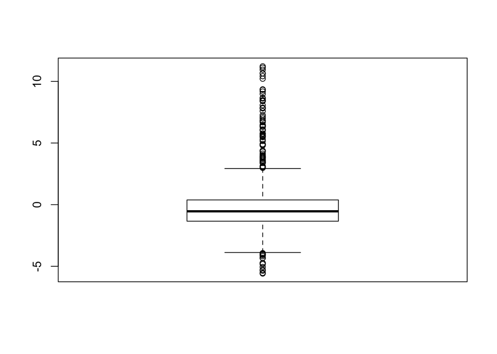

```r
res = residuals(modI7)
boxplot(res)
```

```r
RSS = sum(res^2)

predict(modI7, df, interval='c') # IC para a media
```

```
##               fit          lwr         upr
## 1    2.3481983134  1.131496474  3.56490015
## 2    0.6974528286 -0.735446409  2.13035207
## 3   -0.4570756940 -3.080294998  2.16614361
## 4    0.1056771401 -1.825563928  2.03691821
## 5    1.1499521184 -0.412608505  2.71251274
## 6   -0.5230485972 -1.702112375  0.65601518
## 7    0.6921577712 -1.030789978  2.41510552
## 8    0.3155105637 -1.742054174  2.37307530
## 9    3.0982642030  1.262677635  4.93385077
## 10   0.7494106065 -0.767754038  2.26657525
## 11   5.5360695686  3.781123711  7.29101543
## 12   0.5803839933 -0.433846565  1.59461455
## 13   0.8645725134 -0.693365010  2.42251004
## 14   1.7734024460  0.530078283  3.01672661
```

[output cut: 587 more lines]

```r
predict(modI7, df, interval='p') # IC de predicao. e' mais largo que o da media
```

```
##               fit           lwr       upr
## 1    2.3481983134  -3.418423201  8.114820
## 2    0.6974528286  -5.118624935  6.513531
## 3   -0.4570756940  -6.674377347  5.760226
## 4    0.1056771401  -5.852783432  6.064138
## 5    1.1499521184  -4.699420158  6.999324
## 6   -0.5230485972  -6.281846364  5.235749
## 7    0.6921577712  -5.202085970  6.586402
## 8    0.3155105637  -5.685083822  6.316105
## 9    3.0982642030  -2.829883769  9.026412
## 10   0.7494106065  -5.087998826  6.586820
## 11   5.5360695686  -0.367606853 11.439746
## 12   0.5803839933  -5.146938588  6.307707
## 13   0.8645725134  -4.983566477  6.712712
## 14   1.7734024460  -3.998894783  7.545700
```

[output cut: 587 more lines]

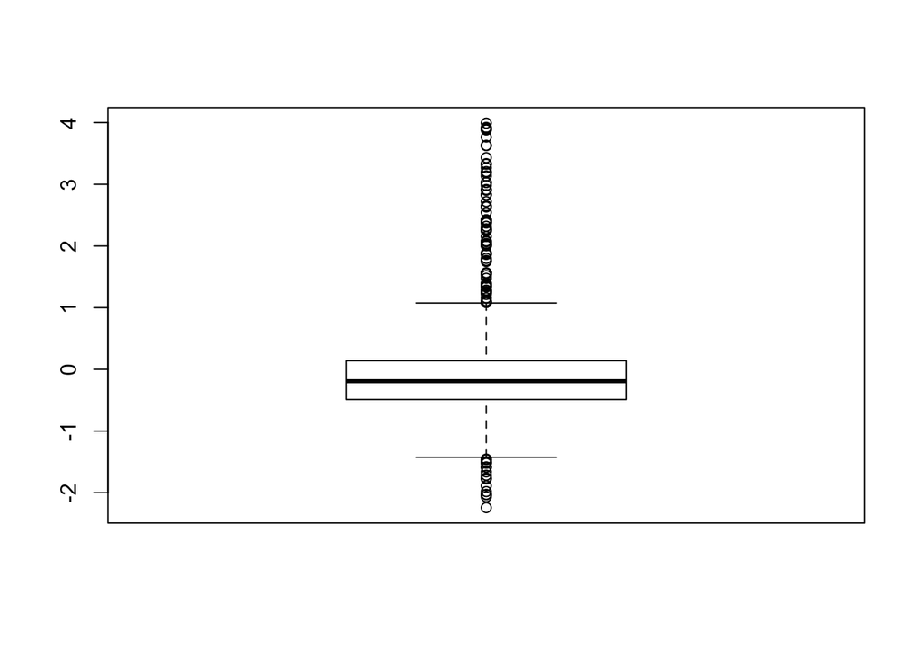

```r
res = rstandard(modI7)
boxplot(res)
```

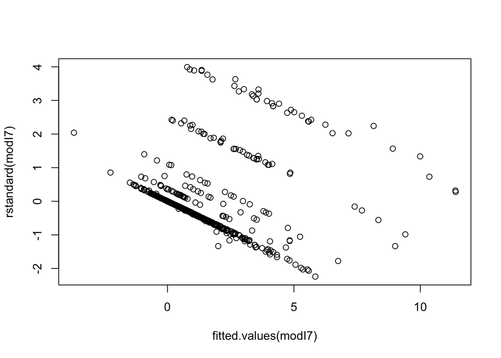

```r
plot(fitted.values(modI7), rstandard(modI7))
```

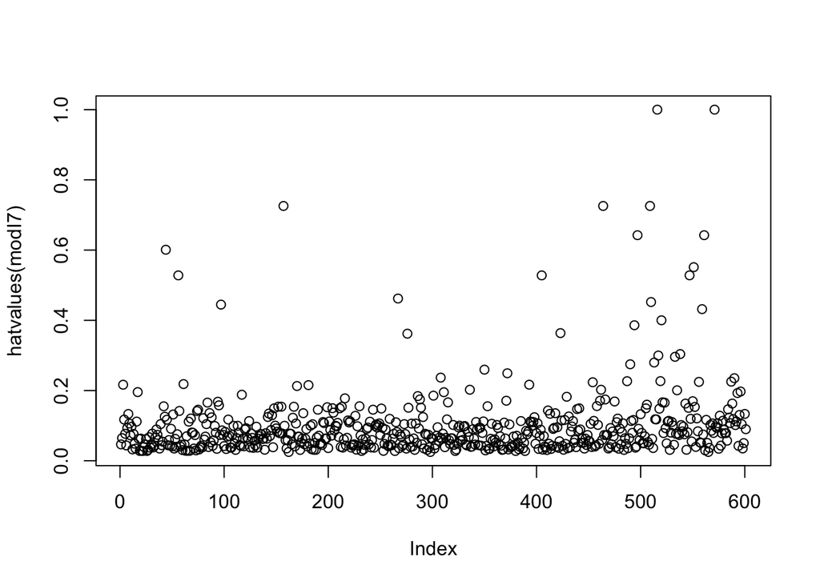

```r
plot(hatvalues(modI7))
```

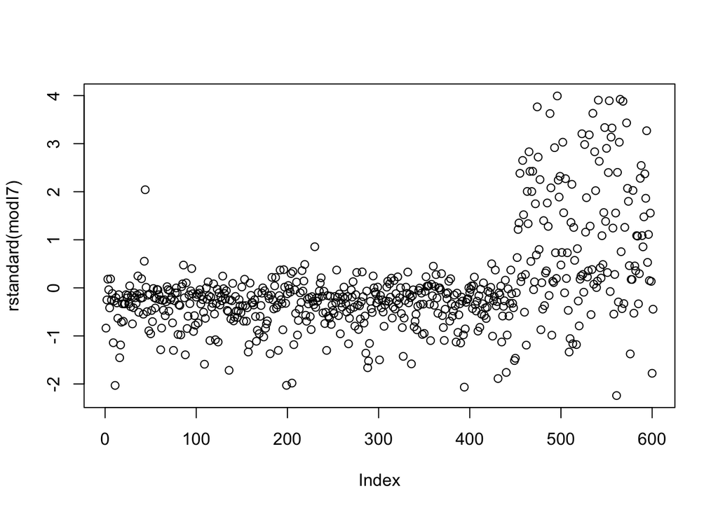

```r
plot(rstandard(modI7))
```

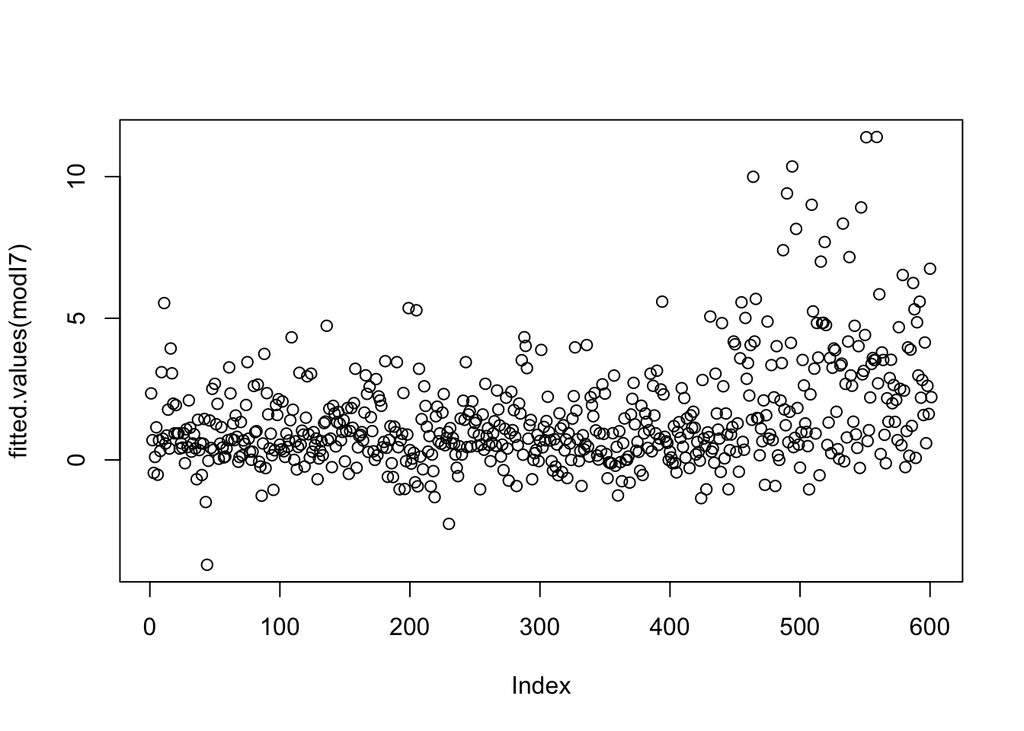

```r
plot(fitted.values(modI7))
```

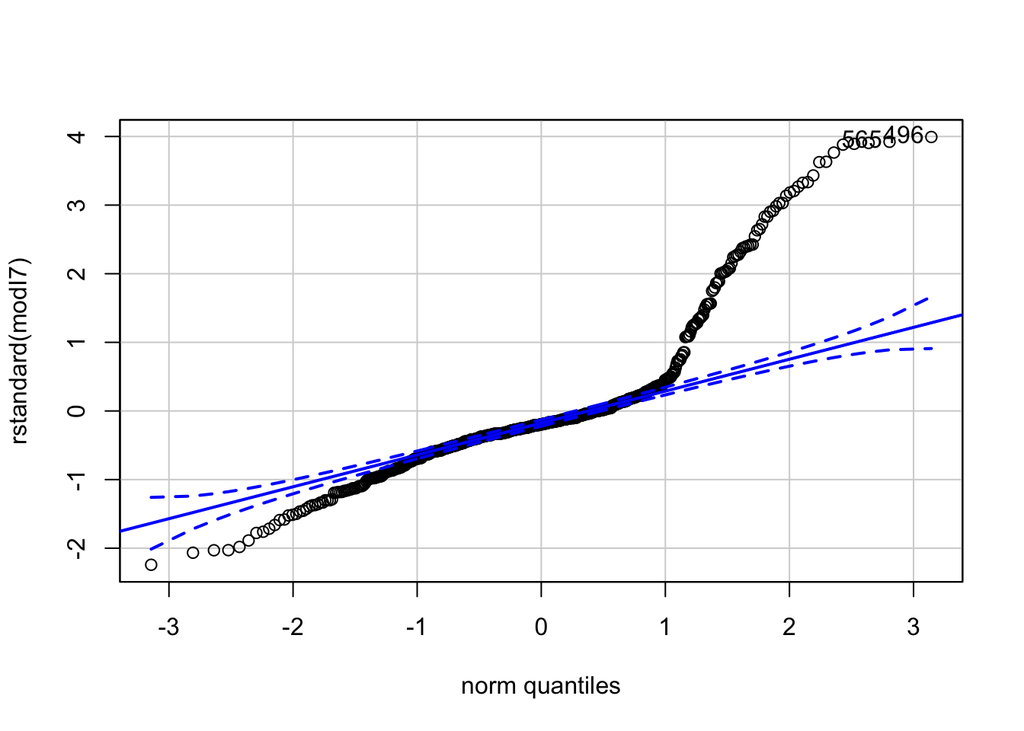

```
## [1] 496 565
```

```r
qqPlot(rstandard(modI7))
```

```r
pred1 <- predict(modI7,df)
pred1
```

```
##             1             2             3             4             5
##  2.3481983134  0.6974528286 -0.4570756940  0.1056771401  1.1499521184
##             6             7             8             9            10
## -0.5230485972  0.6921577712  0.3155105637  3.0982642030  0.7494106065
##            11            12            13            14            15
##  5.5360695686  0.5803839933  0.8645725134  1.7734024460  0.4022459662
##            16            17            18            19            20
##  3.9339266604  3.0576894394  1.9860714205  0.9401416167  1.9333313427
##            21            22            23            24            25
##  0.9401416167  0.9401416167  0.3994117340  0.5921507288  0.4348783392
##            26            27            28            29            30
##  0.9401416167 -0.1160164656  1.0837641421  0.4524031755  2.1015429463
##            31            32            33            34            35
##  1.1376555315  0.2923388339  0.5820765023  0.9056261149  0.4056714568
##            36            37            38            39            40
## -0.6815951237  1.4163407000  0.3471015750  0.5899289822 -0.5321337364
##            41            42            43            44            45
##  0.5737085039  1.4462571155 -1.4866997178 -3.6998205438 -0.0307545807
##            46            47            48            49            50
##  1.3926987750  0.4233344130  2.5088872279  0.3591571878  2.6870252551
##            51            52            53            54            55
##  1.2596505928  1.9802212706  0.0393879973  0.5775497611  1.1575714836
##            56            57            58            59            60
##  0.4411987479  0.0883989818  0.1184707151  0.4037811753  0.6966828396
##            61            62            63            64            65
##  3.2667241987  2.3481983134  0.7367046606  1.2877977982  0.6980999557
##            66            67            68            69            70
##  1.5673680029  0.8158159180 -0.0651280754  0.1031681959  1.3370142014
##            71            72            73            74            75
##  0.1641717923  0.6880807735  0.5671738639  1.9393168773  3.4516531833
##            76            77            78            79            80
##  0.7530489206  0.2923388339  0.0056198326  0.2923388339  2.6096891407
##            81            82            83            84            85
##  0.9800529138  1.0172850722  2.6602619958 -0.0632683584 -0.2325514978
##            86            87            88            89            90
## -1.2635655105  0.5801716395  3.7432084473 -0.2884951690  2.3566362995
##            91            92            93            94            95
##  1.6064794582  0.4033586089  0.9259092741  0.1662015063 -1.0569008163
##            96            97            98            99           100
##  0.3409699827  1.9394668726  1.5869428511  2.1451776312  0.5407527583
```

[output cut: 187 more lines]

```
## -0.1174335817  2.1768184001  1.3487143128  2.8905163746  3.5356891973
##           571           572           573           574           575
##  2.0000000000  2.6458116707  1.3440093721  2.1200115142  0.6995170718
##           576           577           578           579           580
##  4.6835040469  2.5088872279  0.5213705852  6.5266791599  2.4467960040
##           581           582           583           584           585
## -0.2547400475  1.0185224530  3.9724554292  0.1472690923  3.8936091047
##           586           587           588           589           590
##  1.2016352832  6.2454412417  5.3163844216  0.0722838175  4.8581068284
##           591           592           593           594           595
##  2.9829101008  5.5863835604  2.1956065306  2.8219097336  1.5842795021
##           596           597           598           599           600
##  4.1452746334  0.5899289822  2.6158310679  1.6240182790  6.7487545732
##           601
##  2.2164078446
```

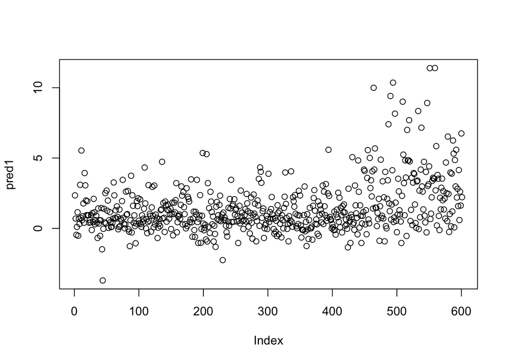

```r
plot(pred1)
```

```r
round.pred <- smart.round(pred1)
round.pred
```

```
##   1   2   3   4   5   6   7   8   9  10  11  12  13  14  15  16  17  18
##   2   1   0   0   1   0   1   0   3   1   6   1   1   2   0   4   3   2
##  19  20  21  22  23  24  25  26  27  28  29  30  31  32  33  34  35  36
##   1   2   1   1   0   1   0   1   0   1   0   2   1   0   1   1   0   0
##  37  38  39  40  41  42  43  44  45  46  47  48  49  50  51  52  53  54
##   1   0   1   0   1   1   0   0   0   1   0   3   0   3   1   2   0   1
##  55  56  57  58  59  60  61  62  63  64  65  66  67  68  69  70  71  72
##   1   0   0   0   0   1   3   2   1   1   1   2   1   0   0   1   0   1
##  73  74  75  76  77  78  79  80  81  82  83  84  85  86  87  88  89  90
##   1   2   3   1   0   0   0   3   1   1   3   0   0   0   1   4   0   2
##  91  92  93  94  95  96  97  98  99 100 101 102 103 104 105 106 107 108
##   2   0   1   0   0   0   2   2   2   1   0   2   0   0   1   0   1   1
## 109 110 111 112 113 114 115 116 117 118 119 120 121 122 123 124 125 126
##   4   2   0   1   0   0   3   1   1   1   0   1   3   1   0   3   0   1
## 127 128 129 130 131 132 133 134 135 136 137 138 139 140 141 142 143 144
```

[output cut: 53 more lines]

```r
mse <- mean((round.pred - df$nbaffairs)^2)
mse
```

```
## [1] 7.296173
```

```r
mae <- mean(abs(round.pred - df$nbaffairs))
mae
```

```
## [1] 1.675541
```

Para garantir que a introdução das novas variáveis não causou overfit, iremos usar cross-validation, testanto o modelo num conjunto de dados diferente do de treino. O training set terá 70% dos dados do dataset original e o testing set os restantes 30%.

```r
trainingRows <- sample(1:nrow(df), 0.7*nrow(df))
training <- df[trainingRows,]
testing <- df[-trainingRows,]

modI7 <- lm(nbaffairs ~ . -rate -age -sex -child -education -occupation +religious:ym +religious:age +religious:rate +occupation:rate +sex:occupation, training)

predictions <- predict(modI7,testing)
predictions <- smart.round(predictions)
mse <- mean((predictions - testing$nbaffairs)^2)
mse
```

```
## [1] 8.165746
```

```r
mae <- mean(abs(predictions - testing$nbaffairs))
mae
```

```
## [1] 1.668508
```

```r
predictions <- predict(modI7,training)
mse <- mean((predictions - training$nbaffairs)^2)
mse
```

```
## [1] 8.074376
```

```r
mae <- mean(abs(predictions - training$nbaffairs))
mae
```

```
## [1] 1.861509
```

The error is high as expected, but it is equivalent in the testing and training sets so there is no overfitting.

```r
summary(modI7)
```

```
##
## Call:
## lm(formula = nbaffairs ~ . - rate - age - sex - child - education -
##     occupation + religious:ym + religious:age + religious:rate +
##     occupation:rate + sex:occupation, data = training)
##
## Residuals:
##     Min      1Q  Median      3Q     Max
## -6.4080 -1.3716 -0.5527  0.3530 11.2612
##
## Coefficients: (1 not defined because of singularities)
##                        Estimate Std. Error t value Pr(>|t|)
## (Intercept)             9.96691    6.41441   1.554 0.121101
## ym                      0.23339    0.19147   1.219 0.223658
## religious2             -5.64752    6.94587  -0.813 0.416711
## religious3              4.48445    6.81590   0.658 0.510996
## religious4             -2.54922    6.07434  -0.420 0.674976
## religious5             -6.99383    7.23498  -0.967 0.334356
## ym:religious2           0.07821    0.21372   0.366 0.714605
## ym:religious3          -0.09111    0.22330  -0.408 0.683498
## ym:religious4          -0.26202    0.20509  -1.278 0.202206
## ym:religious5          -0.12653    0.24026  -0.527 0.598767
## age:religious1         -0.05819    0.15543  -0.374 0.708350
## age:religious2         -0.18159    0.05833  -3.113 0.002000 **
## age:religious3         -0.09073    0.07886  -1.151 0.250686
## age:religious4          0.03721    0.04222   0.881 0.378744
## age:religious5         -0.05402    0.07329  -0.737 0.461530
## religious1:rate2       -2.61318    5.85140  -0.447 0.655439
## religious2:rate2        1.45955    3.58404   0.407 0.684077
## religious3:rate2       -9.04360    2.92760  -3.089 0.002163 **
## religious4:rate2       -5.55760    2.83734  -1.959 0.050913 .
## religious5:rate2       -4.54316    3.80977  -1.193 0.233847
## religious1:rate3       -1.74212    5.52062  -0.316 0.752514
## religious2:rate3        0.47574    3.55345   0.134 0.893571
## religious3:rate3      -10.99405    2.89602  -3.796 0.000172 ***
## religious4:rate3       -7.85531    2.77621  -2.830 0.004922 **
## religious5:rate3       -0.96049    3.01134  -0.319 0.749943
## religious1:rate4      -11.19834    5.30119  -2.112 0.035337 *
## religious2:rate4       -0.26420    3.50295  -0.075 0.939922
## religious3:rate4      -12.16749    2.77055  -4.392 1.48e-05 ***
```

[output cut: 23 more lines]

```
## occupation2.5:rate5     2.05072    1.13803   1.802 0.072380 .
## occupation4:rate5       0.29603    1.03872   0.285 0.775815
## occupation5:rate5       0.76179    0.76835   0.991 0.322120
## occupation6.5:rate5     0.55921    0.97252   0.575 0.565642
## sexmale:occupation1     8.26735    3.17793   2.601 0.009664 **
## sexmale:occupation2.5  -1.77969    1.00958  -1.763 0.078781 .
## sexmale:occupation4     0.15083    0.93633   0.161 0.872113
## sexmale:occupation5     0.44855    0.55065   0.815 0.415854
## sexmale:occupation6.5  -0.25358    0.77353  -0.328 0.743242
## ---
## Signif. codes:  0 '***' 0.001 '**' 0.01 '*' 0.05 '.' 0.1 ' ' 1
##
## Residual standard error: 3.065 on 361 degrees of freedom
## Multiple R-squared:  0.3303, Adjusted R-squared:  0.2227
## F-statistic: 3.069 on 58 and 361 DF,  p-value: 7.76e-11
```

Para responder às questões do enunciado, escolhemos a variável numérica ym e a categórica religious.

3. 1. faça a interpretação dos correspondentes efeitos brutos e ajustados

```r
ym <- lm(nbaffairs ~ ym, df)
summary(ym)
```

```
##
## Call:
## lm(formula = nbaffairs ~ ym, data = df)
##
## Residuals:
##     Min      1Q  Median      3Q     Max
## -2.2106 -1.6575 -0.9937 -0.5974 11.3658
##
## Coefficients:
##             Estimate Std. Error t value Pr(>|t|)
## (Intercept)  0.55122    0.23511   2.345   0.0194 *
## ym           0.11063    0.02377   4.655    4e-06 ***
## ---
## Signif. codes:  0 '***' 0.001 '**' 0.01 '*' 0.05 '.' 0.1 ' ' 1
##
## Residual standard error: 3.243 on 599 degrees of freedom
## Multiple R-squared:  0.03491,    Adjusted R-squared:  0.0333
## F-statistic: 21.67 on 1 and 599 DF,  p-value: 3.996e-06
```

O efeito bruto de ym: para cada incremento no número de anos casados, número de casos extraconjugais aumenta 0.11063. O efeito ajustado de ym: para cada incremento no número de anos casados, número de casos extraconjugais aumenta 0.06846, quando fixadas as restantes variáveis.

```r
religious <- lm(nbaffairs ~ religious, df)
summary(religious)
```

```
##
## Call:
## lm(formula = nbaffairs ~ religious, data = df)
##
## Residuals:
##     Min      1Q  Median      3Q     Max
## -2.5833 -1.6524 -0.8857 -0.8579 11.1421
##
## Coefficients:
##             Estimate Std. Error t value Pr(>|t|)
## (Intercept)   2.5833     0.4706   5.489 5.98e-08 ***
## religious2   -0.9309     0.5351  -1.740  0.08242 .
## religious3   -0.6066     0.5513  -1.100  0.27162
## religious4   -1.7254     0.5267  -3.276  0.00111 **
## religious5   -1.6976     0.6110  -2.778  0.00564 **
## ---
## Signif. codes:  0 '***' 0.001 '**' 0.01 '*' 0.05 '.' 0.1 ' ' 1
##
## Residual standard error: 3.261 on 596 degrees of freedom
## Multiple R-squared:  0.02957,    Adjusted R-squared:  0.02305
## F-statistic:  4.54 on 4 and 596 DF,  p-value: 0.001281
```

Relembrando, a escala da variável religious, é de 1 - nada religioso, 2 - pouco religioso, 3 - moderado, 4 - religioso, 5 - muito religioso.

O efeito bruto de religious: -0.9309 é o decremento do número de casos extraconjugais ao passar de nada religioso para pouco religioso. O efeito ajustado de religious: 0.20279 é o incremento do número de casos extraconjugais ao passar de nada religioso para pouco religioso, quando fixados os valores das outras covariáveis.

A mesma interpretação deve ser feita para os restantes níveis da variável religious. Ou seja, passar de: - moderado para nada religioso: efeito bruto de -0.6066 e efeito ajustado: 7.37466 - religioso para nada religioso: efeito bruto de -1.7254 e efeito ajustado: 2.00127 - muito religioso para nada religioso: efeito bruto de -1.6976 e efeito ajustado: -2.75653

É de notar que muitos dos efeitos trocam de sinal. Isso pode indicar um factor de confundimento.

2. interprete o efeito provocado na resposta por uma mudança da terceira categoria de X2 para a segunda, assim como intervalos de confiança a 95% e a 90% para esse efeito.

```r
df$religious <- relevel(df$religious, ref = 3)
levels(df$religious)
```

```
## [1] "3" "1" "2" "4" "5"
```

```r
modI7 <- lm(nbaffairs ~ . -rate -age -sex -child -education -occupation +religious:ym +religious:age +religious:rate +occupation:rate +sex:occupation, df)
summary(modI7)
```

```
##
## Call:
## lm(formula = nbaffairs ~ . - rate - age - sex - child - education -
##     occupation + religious:ym + religious:age + religious:rate +
##     occupation:rate + sex:occupation, data = df)
##
## Residuals:
##     Min      1Q  Median      3Q     Max
## -5.5864 -1.3411 -0.5396  0.3824 11.2210
##
## Coefficients:
##                        Estimate Std. Error t value Pr(>|t|)
## (Intercept)            12.53357    2.48694   5.040 6.37e-07 ***
## ym                      0.32485    0.08534   3.807 0.000157 ***
## religious1             -7.37466    4.98557  -1.479 0.139668
## religious2             -8.73734    2.69834  -3.238 0.001277 **
## religious4             -5.37339    3.15491  -1.703 0.089108 .
## religious5            -10.13119    3.72403  -2.720 0.006728 **
## ym:religious1          -0.25639    0.15241  -1.682 0.093108 .
## ym:religious2          -0.05360    0.11107  -0.483 0.629582
## ym:religious4          -0.32532    0.10428  -3.120 0.001907 **
## ym:religious5          -0.19927    0.12892  -1.546 0.122759
## age:religious3         -0.18806    0.05694  -3.303 0.001020 **
## age:religious1          0.15410    0.07721   1.996 0.046454 *
## age:religious2         -0.14632    0.04515  -3.241 0.001265 **
## age:religious4          0.02383    0.03464   0.688 0.491871
## age:religious5         -0.04384    0.05127  -0.855 0.392884
## religious3:rate2       -5.70523    2.40794  -2.369 0.018170 *
## religious1:rate2       -1.22422    4.68469  -0.261 0.793943
## religious2:rate2        1.30114    2.16519   0.601 0.548133
## religious4:rate2       -4.81728    2.46993  -1.950 0.051648 .
## religious5:rate2       -0.85986    2.91276  -0.295 0.767951
## religious3:rate3       -7.51886    2.30955  -3.256 0.001203 **
## religious1:rate3       -3.25119    4.47909  -0.726 0.468238
## religious2:rate3       -0.08850    2.13207  -0.042 0.966907
## religious4:rate3       -7.47395    2.45822  -3.040 0.002477 **
## religious5:rate3       -1.01810    2.66853  -0.382 0.702966
## religious3:rate4       -8.09152    2.23929  -3.613 0.000330 ***
## religious1:rate4      -11.57413    4.31512  -2.682 0.007537 **
## religious2:rate4       -0.64837    2.04757  -0.317 0.751629
```

[output cut: 23 more lines]

```
## occupation2.5:rate5     1.83151    0.91685   1.998 0.046259 *
## occupation4:rate5       0.53665    0.76622   0.700 0.483985
## occupation5:rate5       0.58083    0.58569   0.992 0.321783
## occupation6.5:rate5     0.53935    0.76247   0.707 0.479638
## sexmale:occupation1     7.91772    2.93693   2.696 0.007238 **
## sexmale:occupation2.5  -1.35893    0.78570  -1.730 0.084275 .
## sexmale:occupation4     0.44531    0.74925   0.594 0.552532
## sexmale:occupation5     0.28823    0.42673   0.675 0.499682
## sexmale:occupation6.5  -0.11707    0.61280  -0.191 0.848565
## ---
## Signif. codes:  0 '***' 0.001 '**' 0.01 '*' 0.05 '.' 0.1 ' ' 1
##
## Residual standard error: 2.87 on 541 degrees of freedom
## Multiple R-squared:  0.3177, Adjusted R-squared:  0.2433
## F-statistic:  4.27 on 59 and 541 DF,  p-value: < 2.2e-16
```

```r
religious <- lm(nbaffairs ~ religious, df)
summary(religious)
```

```
##
## Call:
## lm(formula = nbaffairs ~ religious, data = df)
##
## Residuals:
##     Min      1Q  Median      3Q     Max
## -2.5833 -1.6524 -0.8857 -0.8579 11.1421
##
## Coefficients:
##             Estimate Std. Error t value Pr(>|t|)
## (Intercept)   1.9767     0.2871   6.886 1.46e-11 ***
## religious1    0.6066     0.5513   1.100  0.27162
## religious2   -0.3243     0.3837  -0.845  0.39835
## religious4   -1.1188     0.3720  -3.008  0.00274 **
## religious5   -1.0910     0.4840  -2.254  0.02455 *
## ---
## Signif. codes:  0 '***' 0.001 '**' 0.01 '*' 0.05 '.' 0.1 ' ' 1
##
## Residual standard error: 3.261 on 596 degrees of freedom
## Multiple R-squared:  0.02957,    Adjusted R-squared:  0.02305
## F-statistic:  4.54 on 4 and 596 DF,  p-value: 0.001281
```

```r
confint(modI7, level = 0.95)
```

```
##                               2.5 %      97.5 %
## (Intercept)             7.648333269 17.41881190
## ym                      0.157217260  0.49248559
## religious1            -17.168105212  2.41878162
## religious2            -14.037852034 -3.43682449
## religious4            -11.570768112  0.82398481
## religious5            -17.446519549 -2.81587036
## ym:religious1          -0.555786389  0.04300572
## ym:religious2          -0.271787042  0.16458274
## ym:religious4          -0.530173586 -0.12047400
## ym:religious5          -0.452502538  0.05397040
## age:religious3         -0.299906891 -0.07621135
## age:religious1          0.002429364  0.30577258
## age:religious2         -0.235006115 -0.05763193
## age:religious4         -0.044221830  0.09187506
## age:religious5         -0.144546930  0.05687028
## religious3:rate2      -10.435291980 -0.97517495
## religious1:rate2      -10.426619086  7.97818599
## religious2:rate2       -2.952066044  5.55435361
## religious4:rate2       -9.669105885  0.03454017
## religious5:rate2       -6.581559374  4.86184452
## religious3:rate3      -12.055649029 -2.98206945
## religious1:rate3      -12.049734988  5.54734824
## religious2:rate3       -4.276648858  4.09965878
## religious4:rate3      -12.302772149 -2.64513191
## religious5:rate3       -6.260053849  4.22384932
## religious3:rate4      -12.490282312 -3.69275808
## religious1:rate4      -20.050579265 -3.09768858
## religious2:rate4       -4.670529763  3.37379292
## religious4:rate4      -13.537167077 -4.13692334
## religious5:rate4       -8.107264531  2.15325798
## religious3:rate5      -13.624193476 -4.71989503
## religious1:rate5      -16.982029930 -0.08691093
## religious2:rate5       -4.660938756  3.41137445
## religious4:rate5      -12.565043841 -3.26737500
## religious5:rate5       -7.171079119  2.96312250
## occupation2.5:rate1   -13.675233086 -1.51172969
## occupation4:rate1       2.196486384 12.90048697
## occupation5:rate1      -6.686842711  1.73339324
## occupation6.5:rate1    -9.652572044  0.39169526
## occupation2.5:rate2    -3.420006521  1.76978292
## occupation4:rate2      -1.865180548  3.54045057
## occupation5:rate2      -0.778247062  3.78862392
## occupation6.5:rate2    -0.472496155  4.27414608
## occupation2.5:rate3    -1.684730268  2.90593862
## occupation4:rate3      -1.871682614  3.26171226
## occupation5:rate3      -2.641649787  0.85904775
## occupation6.5:rate3    -1.476880174  2.62660654
## occupation2.5:rate4     0.641281498  4.41467372
## occupation4:rate4      -1.002620877  2.99018481
## occupation5:rate4       0.155371528  2.71999068
## occupation6.5:rate4     0.096491358  3.36928457
## occupation2.5:rate5     0.030486287  3.63252455
## occupation4:rate5      -0.968481354  2.04178998
## occupation5:rate5      -0.569670822  1.73133883
## occupation6.5:rate5    -0.958410210  2.03711197
## sexmale:occupation1     2.148540443 13.68689791
## sexmale:occupation2.5  -2.902319857  0.18446024
## sexmale:occupation4    -1.026479958  1.91709554
## sexmale:occupation5    -0.550016419  1.12647919
## sexmale:occupation6.5  -1.320819413  1.08668174
```

O intervalo de confiança a 95% é de [-14.037852034, -3.43682449].

```r
confint(modI7, level = 0.90)
```

```
##                                5 %         95 %
## (Intercept)             8.43590583 16.631239339
## ym                      0.18424236  0.465460489
## religious1            -15.58925783  0.839934229
## religious2            -13.18333111 -4.291345411
## religious4            -10.57165971 -0.175123590
## religious5            -16.26718143 -3.995208475
## ym:religious1          -0.50751933 -0.005261335
## ym:religious2          -0.23661242  0.129408125
## ym:religious4          -0.49714878 -0.153498809
## ym:religious5          -0.41167709  0.013144953
## age:religious3         -0.28187538 -0.094242857
## age:religious1          0.02688106  0.281320882
## age:religious2         -0.22070845 -0.071929594
## age:religious4         -0.03325142  0.080904650
## age:religious5         -0.12831122  0.040634568
## religious3:rate2       -9.67273685 -1.737730081
## religious1:rate2       -8.94305620  6.494623107
## religious2:rate2       -2.26638595  4.868673517
## religious4:rate2       -8.88692052 -0.747645191
## religious5:rate2       -5.65913671  3.939421857
## religious3:rate3      -11.32425166 -3.713466816
## religious1:rate3      -10.63128043  4.128893682
## religious2:rate3       -3.60145675  3.424466670
## religious4:rate3      -11.52429519 -3.423608870
## religious5:rate3       -5.41497401  3.378769483
## religious3:rate4      -11.78113704 -4.401903352
## religious1:rate4      -18.68405137 -4.464216471
## religious2:rate4       -4.02209809  2.725361241
## religious4:rate4      -12.77943818 -4.894652242
## religious5:rate4       -7.28019082  1.326184267
## religious3:rate5      -12.90644142 -5.437647085
## religious1:rate5      -15.62015886 -1.448782000
## religious2:rate5       -4.01025084  2.760686532
## religious4:rate5      -11.81558323 -4.016835613
## religious5:rate5       -6.35418780  2.146231189
## occupation2.5:rate1   -12.69476510 -2.492197681
## occupation4:rate1       3.05930769 12.037665660
## occupation5:rate1      -6.00810966  1.054660185
## occupation6.5:rate1    -8.84293010 -0.417946684
## occupation2.5:rate2    -3.00167126  1.351447651
## occupation4:rate2      -1.42944685  3.104716873
## occupation5:rate2      -0.41012361  3.420500473
## occupation6.5:rate2    -0.08988182  3.891531747
## occupation2.5:rate3    -1.31468853  2.535896883
## occupation4:rate3      -1.45789317  2.847922813
## occupation5:rate3      -2.35946777  0.576865741
## occupation6.5:rate3    -1.14610891  2.295835278
## occupation2.5:rate4     0.94544471  4.110510505
## occupation4:rate4      -0.68077132  2.668335256
## occupation5:rate4       0.36209873  2.513263479
## occupation6.5:rate4     0.36030260  3.105473327
## occupation2.5:rate5     0.32083711  3.342173724
## occupation4:rate5      -0.72583131  1.799139932
## occupation5:rate5      -0.38419249  1.545860497
## occupation6.5:rate5    -0.71694905  1.795650810
## sexmale:occupation1     3.07861706 12.756821284
## sexmale:occupation2.5  -2.65350264 -0.064356980
## sexmale:occupation4    -0.78920609  1.679821669
## sexmale:occupation5    -0.41487852  0.991341288
## sexmale:occupation6.5  -1.12675708  0.892619412
```

O intervalo de confiança a 90% é de [-13.18333111, -4.291345411].

```r
df$religious <- relevel(df$religious, ref = 1)
```

```r
(max(df$ym) - min(df$ym)) * 0.2
```

```
## [1] 2.975
```

```r
modSignif <- lm(nbaffairs ~ age+ym+religious+rate, df)
summary(modSignif)
```

```
##
## Call:
## lm(formula = nbaffairs ~ age + ym + religious + rate, data = df)
##
## Residuals:
##     Min      1Q  Median      3Q     Max
## -4.8279 -1.4929 -0.7237  0.1635 12.7560
##
## Coefficients:
##             Estimate Std. Error t value Pr(>|t|)
## (Intercept)  3.97830    0.96901   4.106 4.60e-05 ***
## age         -0.04222    0.02155  -1.959  0.05058 .
## ym           0.15433    0.03656   4.221 2.81e-05 ***
## religious1   0.93960    0.51914   1.810  0.07082 .
## religious2  -0.21544    0.36221  -0.595  0.55221
## religious4  -1.10261    0.35208  -3.132  0.00182 **
## religious5  -1.11473    0.46261  -2.410  0.01627 *
## rate2        0.30786    0.85506   0.360  0.71894
## rate3       -2.00051    0.83436  -2.398  0.01681 *
## rate4       -2.17927    0.80147  -2.719  0.00674 **
## rate5       -2.51654    0.80611  -3.122  0.00189 **
## ---
## Signif. codes:  0 '***' 0.001 '**' 0.01 '*' 0.05 '.' 0.1 ' ' 1
##
## Residual standard error: 3.06 on 590 degrees of freedom
## Multiple R-squared:  0.1538, Adjusted R-squared:  0.1395
## F-statistic: 10.73 on 10 and 590 DF,  p-value: < 2.2e-16
```

```r
mod20ym <- lm(nbaffairs ~ age+I(2.975*ym)+religious+rate, df)
summary(mod20ym)
```

```
##
## Call:
## lm(formula = nbaffairs ~ age + I(2.975 * ym) + religious + rate,
##     data = df)
##
## Residuals:
##     Min      1Q  Median      3Q     Max
## -4.8279 -1.4929 -0.7237  0.1635 12.7560
##
## Coefficients:
##               Estimate Std. Error t value Pr(>|t|)
## (Intercept)    3.97830    0.96901   4.106 4.60e-05 ***
## age           -0.04222    0.02155  -1.959  0.05058 .
## I(2.975 * ym)  0.05188    0.01229   4.221 2.81e-05 ***
## religious1     0.93960    0.51914   1.810  0.07082 .
## religious2    -0.21544    0.36221  -0.595  0.55221
## religious4    -1.10261    0.35208  -3.132  0.00182 **
## religious5    -1.11473    0.46261  -2.410  0.01627 *
## rate2          0.30786    0.85506   0.360  0.71894
## rate3         -2.00051    0.83436  -2.398  0.01681 *
## rate4         -2.17927    0.80147  -2.719  0.00674 **
## rate5         -2.51654    0.80611  -3.122  0.00189 **
## ---
## Signif. codes:  0 '***' 0.001 '**' 0.01 '*' 0.05 '.' 0.1 ' ' 1
##
## Residual standard error: 3.06 on 590 degrees of freedom
## Multiple R-squared:  0.1538, Adjusted R-squared:  0.1395
## F-statistic: 10.73 on 10 and 590 DF,  p-value: < 2.2e-16
```